# Data Wrangling with R

IBM 320 Section 02

Author

Elijah Kates

Published

March 18, 2026

Note: This codebook will follow the structure and content of the published codebook of the project: [Data Wrangling with Tidyverse](https://jmjung.quarto.pub/m05-1-principles-data-wrangling-with-tidyverse-in-r/)

# Overview

## Learning Outcomes

By the end of this module, you will be able to:

- Describe the concept of Data Wrangling
- Describe how Tibbles are different from data frames
- Explain how to convert wide or long data to tidy data
- Explain how to merge relational data sets using join functions (next module)
- Explain how to use grouped mutates and filter together
- Be familiar with major dplyr functions for transforming data
- Create a new variable with `mutate()` and `case_when()`
- Use the pipe operator to shape data for analysis and visualization

## The textbook chapters to cover

- Ch3: Data Transformation
- Ch5: Data Tidying
- Ch13: Numbers

# Introduction to Data Wrangling

Data wrangling refers to the process of cleaning, transforming, and organizing raw data into a format that can be used for analysis.

# Loading the Library

```r
library(tidyverse)
```

# What is Tidyverse

The **tidyverse** is a collection of R packages designed for data science that share a common philosophy and grammar.

Core packages include:

- **ggplot2** for data visualization
- **dplyr** for data manipulation
- **tidyr** for data tidying
- **readr** for data import
- **purrr** for functional programming
- **tibble** for modern data frames
- **stringr** for string manipulation
- **forcats** for categorical variables

# Initial Data Preparation and Exploration

```r
library(nycflights13)
data()
```

# Data Wrangling in dplyr

The **dplyr** package provides functions for manipulating data.

Note: use `Shift + Option + I` for multi-cursor activation

`airlines` Airline names.  
`airports` Airport metadata.  
`flights` Flights data.  
`planes` Plane metadata.  
`weather` Hourly weather data.

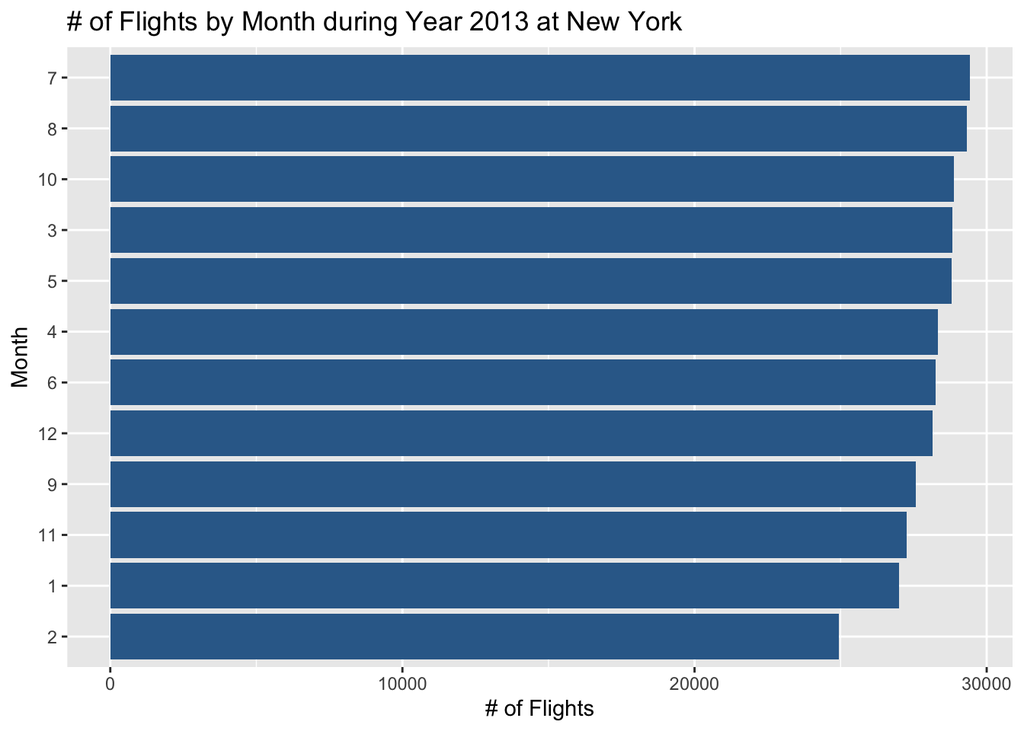

```r
flights <- flights

flights |>
    count(year, month) |>
    arrange(desc(n)) |>
    mutate(month = as_factor(month)) |>
    mutate(month = fct_reorder(month, n)) |>
    ggplot(aes(month, n, fill = year)) +
    geom_col(show.legend = FALSE) + coord_flip() +
    labs(x = "Month", y = "# of Flights", title = "# of Flights by Month during Year 2013 at New York"
    )
```